# 04_MB_Xeno_LDA_workflow

2023-11-13

```r
#library(phyloseq)
library(dplyr)
library(magrittr)
library(ggplot2)
library(stringr)
#library(genefilter)
library(rstan)
library(randomcoloR)
library(SpatialExperiment)
#library(DESeq2)
library(here)
```

```r
theme_set(theme_minimal())
theme_update(
  text = element_text(size = 10),
  legend.text = element_text(size = 10)
)

# force not to use scientific notation
options(scipen=999)
```

## Dataset

Load the MB_Xeno SPE object.

```r
load(file = here("04_MB_Xeno_LDA","02_MB_Xeno_spe.rds"))
spe
```

```
## class: SpatialExperiment
## dim: 70 562226
## metadata(0):
## assays(1): ''
## rownames(70): dsDNA_asinh_znorm HLA_asinh_znorm ... Vimentin_asinh
##   VWF_asinh
## rowData names(0):
## colnames: NULL
## colData names(19): sample_id raw_id ... eccentricity tissue_id
## reducedDimNames(0):
## mainExpName: NULL
## altExpNames(0):
## spatialCoords names(2) : centroidX centroidY
## imgData names(0):
```

## Sample Data

We want to first apply the Latent Dirichlet Allocation to the sample data with tissue c5m1_AML and tissue c2m1_CB and find topics in their celluar neighbourhood.

```r
spe_sample <- spe[, spe$tissue_id %in% c("c5m1_AML", "c2m1_CB")]
spe_sample
```

```
## class: SpatialExperiment
## dim: 70 204701
## metadata(0):
## assays(1): ''
## rownames(70): dsDNA_asinh_znorm HLA_asinh_znorm ... Vimentin_asinh
##   VWF_asinh
## rowData names(0):
## colnames: NULL
## colData names(19): sample_id raw_id ... eccentricity tissue_id
## reducedDimNames(0):
## mainExpName: NULL
## altExpNames(0):
## spatialCoords names(2) : centroidX centroidY
## imgData names(0):
```

### Document-Term Matrix

We then want to create the Document-Term matrix with the sample dataset, where the rows are the documents (sample) and the columns are the words(cell-type) and filled with counts.

```r
# create document-term matrix
dtm_sample <- table(spe_sample$tissue_id, spe_sample$cluster_id)

# dimension of document-term matrix
dim(dtm_sample)
```

```
## [1]  2 33
```

We next to acquire the column names of the sample Document-Term matrix for further usage, and we set the colnames of the matrix to `NULL` as no names should be apply to the LDA function.

```r
# column names of document-term matrix
col_names_sample <- colnames(dtm_sample)
col_names_sample
```

```
##  [1] "engrafted_cluster_1"   "engrafted_cluster_10"  "engrafted_cluster_2"
##  [4] "engrafted_cluster_3"   "engrafted_cluster_4"   "engrafted_cluster_5"
##  [7] "engrafted_cluster_6"   "engrafted_cluster_7"   "engrafted_cluster_8"
## [10] "engrafted_cluster_9"   "mousehem_cluster_1"    "mousehem_cluster_10"
## [13] "mousehem_cluster_11"   "mousehem_cluster_12"   "mousehem_cluster_2"
## [16] "mousehem_cluster_3"    "mousehem_cluster_4"    "mousehem_cluster_5"
## [19] "mousehem_cluster_6"    "mousehem_cluster_7"    "mousehem_cluster_8"
## [22] "mousehem_cluster_9"    "mouseniche_cluster_1"  "mouseniche_cluster_10"
## [25] "mouseniche_cluster_2"  "mouseniche_cluster_3"  "mouseniche_cluster_4"
## [28] "mouseniche_cluster_5"  "mouseniche_cluster_6"  "mouseniche_cluster_7"
## [31] "mouseniche_cluster_8"  "mouseniche_cluster_9"  "unassigned"
```

```r
# setting column names to NULL
colnames(dtm_sample) <- NULL
```

```r
# Colour
# plant_colors <- c("#999999", "#E69F00", "#56B4E9", "#009E73", "#F0E442", "#0072B2", "#D55E00", "#CC79A7", "purple")
```

### Input sample data for LDA

```r
K <- 3
alpha <- 0.8
gamma <- 0.8
x <- dtm_sample
# View(x)
dimnames(x) <- NULL

# theta[d] ~ dirichlet(alpha), alpha pseudo-count for each topic
# beta[k] ~ dirichlet(gamma), gamma pseudo-count for each ASV in each topic

# n is DTM
stan.data <- list(K = K,
  V = ncol(x),
  D = nrow(x),
  n = x,
  alpha = rep(alpha, K),
  gamma = rep(gamma, ncol(x))
)
```

### Posterior sampling

We want to estimate the parameters $\theta$ and $B = \left[\beta_{1}, \cdots, \beta_{K} \right]^{T}$, and we estimate using Hamiltonian Monte Carlo(HMC) No-U-Turn-Sampler(NUTS) with one chain and 500 iterations. Out of these 500 iterations, 250 iteration were used as warm-up samples. We uses high-performance computing and save the results with specified file name.

We first want to specify a file name to save the results.

```r
# number of iteration
iter <- 500
# file name
fileN <- paste0(
  "JABES_Endo_all_K_",
  K,
  "_ite_",
  iter,
  "_sample",
  ".RData"
  )
```

By setting the number of chains to one, we apply with the sample dataset.

```r
#set.seed(4547834)
set.seed(19991116)

# number of chains
chains <- 1

# apply dataset
t1 <- proc.time()
stan.fit <- stan(
  file =  here::here("04_MB_Xeno_LDA","lda.stan"),
  data = stan.data, # must be list object
  iter = iter,
  chains = 1,
  sample_file = NULL,
  diagnostic_file = NULL,
  cores = 4,
  control = list(adapt_delta = 0.9),
  save_dso = TRUE,
  algorithm = "NUTS")
proc.time() - t1

save(stan.fit,
     file = here::here("04_MB_Xeno_LDA","04_LDA_workflow"))
```

We then load the file from the directory and perform further analysis.

We extract posterior samples from the results.

```r
sample_result <- rstan::extract(
  stan.fit,
  permuted = TRUE,
  inc_warmup = FALSE,
  include = TRUE
  )
```

### Topics analysis

We would like to analyze the results from applying LDA to the sample dataset. Since we are interested in the parameters $\theta$ and $B = \left[\beta_{1}, \cdots, \beta_{K} \right]^{T}$, we want to extract them from the results and check their dimensions.

#### $\theta$

We start with $\theta$. The dimension of $\theta$ is 250 x 2 x 3, where 250 is the number of iteration with 2 tissues and 3 topics. Each value is the probability of each tissue in each topic in each iteration.

```r
theta_sample <- sample_result$theta
dim(theta_sample)
```

```
## [1] 250   2   3
```

We first want to extract tissue “c5m1_AML”, and then find the median and mean of probabilities in each topic out of the 250 runs. From both results, we can easily see both methods agree tissue “c5m1_AML” is $98/%$ topic 2 and tissue “c2m1_CB” is $99/%$ topic 1.

```r
# tissue "c5m1_AML"
#theta_sample[, 1, ]
print("--- Tissue 'c5m1_AML'---")
```

```
## [1] "--- Tissue 'c5m1_AML'---"
```

```r
print("----- Median Probabilities -----")
```

```
## [1] "----- Median Probabilities -----"
```

```r
apply(data.frame(theta_sample[, 1, ]), 2, median)
```

```
##           X1           X2           X3
## 0.0174061023 0.9812891951 0.0009893467
```

```r
print("----- Mean Probabilities -----")
```

```
## [1] "----- Mean Probabilities -----"
```

```r
apply(data.frame(theta_sample[, 1, ]), 2, mean)
```

```
##          X1          X2          X3
## 0.021227925 0.977454294 0.001317781
```

```r
# Tissue  "c2m1_CB"
#theta_sample[, 2, ]
print("--- tissue 'c2m1_CB' ---")
```

```
## [1] "--- tissue 'c2m1_CB' ---"
```

```r
print("----- Median Probabilities -----")
```

```
## [1] "----- Median Probabilities -----"
```

```r
apply(data.frame(theta_sample[, 2, ]), 2, median)
```

```
##           X1           X2           X3
## 0.9975492506 0.0022006228 0.0001195643
```

```r
print("----- Mean Probabilities -----")
```

```
## [1] "----- Mean Probabilities -----"
```

```r
apply(data.frame(theta_sample[, 2, ]), 2, mean)
```

```
##           X1           X2           X3
## 0.9972747250 0.0024807305 0.0002445445
```

We can also plot the probability distribution for each topic in tissue “c5m1_AML”.

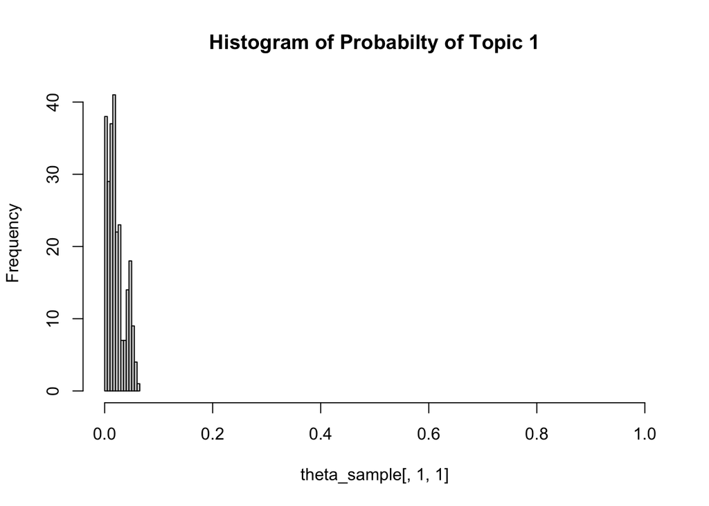

```r
# tissue "c5m1_AML"
# topic 1
hist(theta_sample[, 1, 1], xlim = c(0,1),
     main = "Histogram of Probabilty of Topic 1")
```

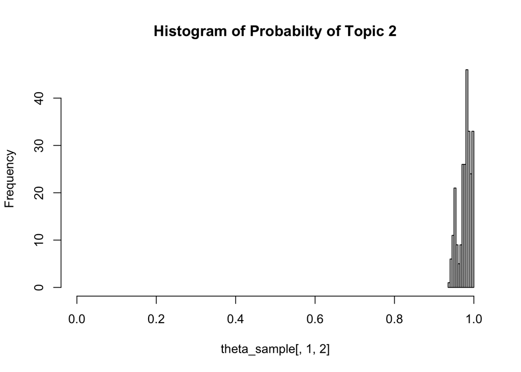

```r
# topic 2
hist(theta_sample[, 1, 2], xlim = c(0,1),
     main = "Histogram of Probabilty of Topic 2")
```

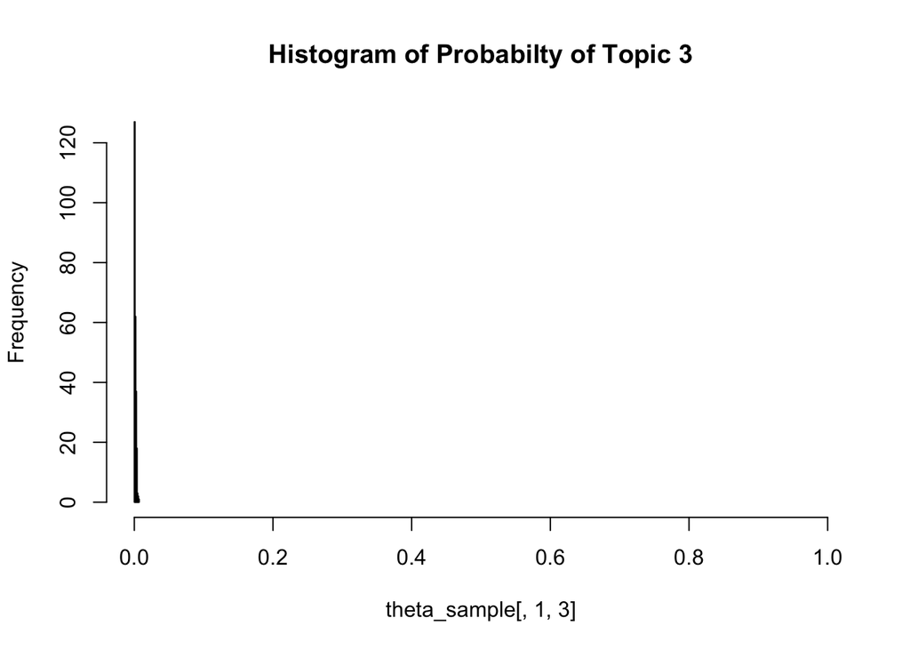

```r
# topic 3
hist(theta_sample[, 1, 3], xlim = c(0,1),
     main = "Histogram of Probabilty of Topic 3")
```

We are now interest what cell types are in each topics, thus we want to preform analysis with $\beta$ estimation. Each value is the probability of each cell type in each topic in each iterations.

```r
# extract beta estimation
beta_sample <- sample_result$beta

# set dimension names for cell type column
dimnames(beta_sample)[3] <- list(col_names_sample)
dim(beta_sample)
```

```
## [1] 250   3  33
```

We want to extract tissue “c5m1_AML”, and then find the median and mean of the probability of each cell type in each topics.

```r
print("--- Topic 1---")
```

```
## [1] "--- Topic 1---"
```

```r
print("----- Mean -----")
```

```
## [1] "----- Mean -----"
```

```r
apply(data.frame(beta_sample[, 1, ]), 2, mean) %>% sort(decreasing = TRUE)
```

```
##  mouseniche_cluster_3   engrafted_cluster_4   engrafted_cluster_8
##        0.541418436093        0.260243168722        0.046168295638
##   engrafted_cluster_7  mouseniche_cluster_4  mouseniche_cluster_5
##        0.037932526639        0.030915824851        0.022025716911
##    mousehem_cluster_3    mousehem_cluster_9    mousehem_cluster_6
##        0.013560709282        0.012505908998        0.008588978777
##  mouseniche_cluster_8   engrafted_cluster_9    mousehem_cluster_1
##        0.005980619828        0.003731058341        0.003653178517
##   engrafted_cluster_6   engrafted_cluster_1   engrafted_cluster_5
##        0.002215255887        0.002181530834        0.001840224539
##   engrafted_cluster_3            unassigned  mouseniche_cluster_6
##        0.001745879785        0.000786901758        0.000729809047
## mouseniche_cluster_10   engrafted_cluster_2  mouseniche_cluster_9
##        0.000683011087        0.000681604163        0.000603040165
##  engrafted_cluster_10  mouseniche_cluster_2    mousehem_cluster_7
##        0.000431474755        0.000348729110        0.000312523337
##   mousehem_cluster_10    mousehem_cluster_2    mousehem_cluster_4
##        0.000242633951        0.000131817888        0.000120661226
##  mouseniche_cluster_7  mouseniche_cluster_1   mousehem_cluster_11
##        0.000085902586        0.000083582337        0.000016063087
##   mousehem_cluster_12    mousehem_cluster_8    mousehem_cluster_5
##        0.000013897158        0.000012797915        0.000008236788
```

```r
print("----- Median -----")
```

```
## [1] "----- Median -----"
```

```r
apply(data.frame(beta_sample[, 1, ]), 2, median) %>% sort(decreasing = TRUE)
```

```
##  mouseniche_cluster_3   engrafted_cluster_4   engrafted_cluster_8
##        0.541441737324        0.260169142215        0.046126608854
##   engrafted_cluster_7  mouseniche_cluster_4  mouseniche_cluster_5
##        0.037971405368        0.030912100935        0.022017070313
##    mousehem_cluster_3    mousehem_cluster_9    mousehem_cluster_6
##        0.013560991942        0.012515783679        0.008616681203
##  mouseniche_cluster_8   engrafted_cluster_9    mousehem_cluster_1
##        0.005972645220        0.003718688379        0.003652282213
##   engrafted_cluster_6   engrafted_cluster_1   engrafted_cluster_5
##        0.002212800564        0.002182016239        0.001842402036
##   engrafted_cluster_3            unassigned  mouseniche_cluster_6
##        0.001741938999        0.000784066649        0.000730746615
## mouseniche_cluster_10   engrafted_cluster_2  mouseniche_cluster_9
##        0.000683124866        0.000681928108        0.000592166747
##  engrafted_cluster_10  mouseniche_cluster_2    mousehem_cluster_7
##        0.000431922991        0.000346072827        0.000314982399
##   mousehem_cluster_10    mousehem_cluster_2    mousehem_cluster_4
##        0.000237522950        0.000133736362        0.000117474654
##  mouseniche_cluster_7  mouseniche_cluster_1   mousehem_cluster_11
##        0.000083134590        0.000079707434        0.000013020825
##   mousehem_cluster_12    mousehem_cluster_8    mousehem_cluster_5
##        0.000010661905        0.000007564674        0.000005166413
```

From the above results for Topic 1, we can clearly see both methods agree that mouseniche_cluster_3, engrafted_cluster_4, engrafted_cluster_8 dominate topic 1.

```r
print("--- Topic 2---")
```

```
## [1] "--- Topic 2---"
```

```r
print("----- Mean -----")
```

```
## [1] "----- Mean -----"
```

```r
apply(data.frame(beta_sample[, 2, ]), 2, mean) %>% sort(decreasing = TRUE)
```

```
##  mouseniche_cluster_3    mousehem_cluster_6    mousehem_cluster_9
##         0.58629932034         0.15132112350         0.08757680720
##   engrafted_cluster_4    mousehem_cluster_7    mousehem_cluster_3
##         0.04937049467         0.02150537393         0.02093914555
##  mouseniche_cluster_8   engrafted_cluster_8   engrafted_cluster_1
##         0.01746760263         0.01399042804         0.01115479328
##   engrafted_cluster_7 mouseniche_cluster_10    mousehem_cluster_8
##         0.00570459716         0.00497607067         0.00471277973
##   mousehem_cluster_10  mouseniche_cluster_9    mousehem_cluster_1
##         0.00421053092         0.00343538065         0.00305454159
##    mousehem_cluster_2    mousehem_cluster_4  mouseniche_cluster_5
##         0.00245431886         0.00191126743         0.00176873570
##  mouseniche_cluster_4  mouseniche_cluster_2   mousehem_cluster_12
##         0.00136617755         0.00119751941         0.00118879080
##   engrafted_cluster_3   engrafted_cluster_9  mouseniche_cluster_7
##         0.00105872402         0.00077078940         0.00059362509
##  mouseniche_cluster_1   engrafted_cluster_5    mousehem_cluster_5
##         0.00057241696         0.00053152420         0.00030311149
##            unassigned  engrafted_cluster_10   mousehem_cluster_11
##         0.00016609348         0.00013395335         0.00011345465
##   engrafted_cluster_2  mouseniche_cluster_6   engrafted_cluster_6
##         0.00007315804         0.00005710017         0.00002024952
```

```r
print("----- Median -----")
```

```
## [1] "----- Median -----"
```

```r
apply(data.frame(beta_sample[, 2, ]), 2, median) %>% sort(decreasing = TRUE)
```

```
##  mouseniche_cluster_3    mousehem_cluster_6    mousehem_cluster_9
##         0.58608726361         0.15081186462         0.08743660610
##   engrafted_cluster_4    mousehem_cluster_7    mousehem_cluster_3
##         0.05022646055         0.02147064617         0.02092356932
##  mouseniche_cluster_8   engrafted_cluster_8   engrafted_cluster_1
##         0.01749580242         0.01406497764         0.01114451595
##   engrafted_cluster_7 mouseniche_cluster_10    mousehem_cluster_8
##         0.00576826104         0.00495333699         0.00472700513
##   mousehem_cluster_10  mouseniche_cluster_9    mousehem_cluster_1
##         0.00420541879         0.00344521872         0.00306451094
##    mousehem_cluster_2    mousehem_cluster_4  mouseniche_cluster_5
##         0.00245657754         0.00191633535         0.00186643935
##  mouseniche_cluster_4  mouseniche_cluster_2   mousehem_cluster_12
##         0.00148077176         0.00120378949         0.00119282656
##   engrafted_cluster_3   engrafted_cluster_9  mouseniche_cluster_7
##         0.00106138277         0.00077588011         0.00059829602
##  mouseniche_cluster_1   engrafted_cluster_5    mousehem_cluster_5
##         0.00057251018         0.00053979557         0.00030369909
##            unassigned  engrafted_cluster_10   mousehem_cluster_11
##         0.00016843668         0.00014243554         0.00011233542
##   engrafted_cluster_2  mouseniche_cluster_6   engrafted_cluster_6
##         0.00007085421         0.00005621310         0.00001341279
```

From the above results for Topic 2, we can clearly see both methods agree that mouseniche_cluster_3, mousehem_cluster_6, mousehem_cluster_9 dominate topic 2.

```r
print("--- Topic 3---")
```

```
## [1] "--- Topic 3---"
```

```r
print("----- Mean -----")
```

```
## [1] "----- Mean -----"
```

```r
apply(data.frame(beta_sample[, 3, ]), 2, mean) %>% sort(decreasing = TRUE)
```

```
##    mousehem_cluster_2   engrafted_cluster_7   engrafted_cluster_9
##            0.03648428            0.03611944            0.03587846
##  mouseniche_cluster_5   engrafted_cluster_4  engrafted_cluster_10
##            0.03531308            0.03523089            0.03499524
##    mousehem_cluster_7  mouseniche_cluster_1   engrafted_cluster_5
##            0.03438152            0.03419226            0.03344773
##    mousehem_cluster_3  mouseniche_cluster_4   engrafted_cluster_8
##            0.03321132            0.03271540            0.03225594
##    mousehem_cluster_4   engrafted_cluster_1    mousehem_cluster_6
##            0.03190868            0.03188851            0.03176956
##  mouseniche_cluster_2 mouseniche_cluster_10  mouseniche_cluster_8
##            0.03176122            0.03164725            0.03152811
##    mousehem_cluster_1            unassigned  mouseniche_cluster_3
##            0.03097733            0.03090374            0.03006750
##  mouseniche_cluster_7    mousehem_cluster_9   mousehem_cluster_10
##            0.02966889            0.02957774            0.02933343
##   engrafted_cluster_3  mouseniche_cluster_9   engrafted_cluster_2
##            0.02889907            0.02857597            0.02605849
##   mousehem_cluster_12  mouseniche_cluster_6    mousehem_cluster_8
##            0.02549066            0.02499039            0.02341295
##   mousehem_cluster_11    mousehem_cluster_5   engrafted_cluster_6
##            0.02280620            0.02139083            0.01311794
```

```r
print("----- Median -----")
```

```
## [1] "----- Median -----"
```

```r
apply(data.frame(beta_sample[, 3, ]), 2, median) %>% sort(decreasing = TRUE)
```

```
##  engrafted_cluster_10   engrafted_cluster_9   engrafted_cluster_7
##           0.027638448           0.026906234           0.023763724
##    mousehem_cluster_2   engrafted_cluster_4   engrafted_cluster_8
##           0.023759840           0.023232746           0.022561289
##   engrafted_cluster_5    mousehem_cluster_3            unassigned
##           0.022418889           0.022333402           0.021668917
##  mouseniche_cluster_1    mousehem_cluster_6  mouseniche_cluster_5
##           0.021568283           0.021164743           0.021040927
##  mouseniche_cluster_8  mouseniche_cluster_9    mousehem_cluster_4
##           0.020939685           0.020510687           0.020372295
##  mouseniche_cluster_2   engrafted_cluster_3    mousehem_cluster_1
##           0.020187716           0.019741991           0.019558387
##  mouseniche_cluster_4    mousehem_cluster_7   mousehem_cluster_10
##           0.019504915           0.019383772           0.019344024
##    mousehem_cluster_9  mouseniche_cluster_7   engrafted_cluster_1
##           0.019165674           0.018383220           0.018235535
##  mouseniche_cluster_3 mouseniche_cluster_10   engrafted_cluster_2
##           0.017543364           0.016999525           0.016787258
##   mousehem_cluster_11    mousehem_cluster_8  mouseniche_cluster_6
##           0.016232602           0.016049507           0.015859076
##   mousehem_cluster_12    mousehem_cluster_5   engrafted_cluster_6
##           0.014796039           0.014247515           0.008673434
```

From the above results for Topic 3, the two methods has disagreement in the order and proportion of cell types dominating topic 3, there is no cell type that has a significantly higher proportion.

## Application

```r
# Inspect complete dataset
spe
```

```
## class: SpatialExperiment
## dim: 70 562226
## metadata(0):
## assays(1): ''
## rownames(70): dsDNA_asinh_znorm HLA_asinh_znorm ... Vimentin_asinh
##   VWF_asinh
## rowData names(0):
## colnames: NULL
## colData names(19): sample_id raw_id ... eccentricity tissue_id
## reducedDimNames(0):
## mainExpName: NULL
## altExpNames(0):
## spatialCoords names(2) : centroidX centroidY
## imgData names(0):
```

### Document-Term Matrix

We first want to create the document-term matrix of the dataset where the rows are the sample identity and columns are the cell types fill with counts. The expected dimension of the DTM is 9 rows by 33 columns.

```r
dtm <- table(spe$tissue_id, spe$cluster_id)
dim(dtm)
```

```
## [1]  9 33
```

```r
dim_names <- dimnames(dtm)
col_names <- colnames(dtm)
```

```r
get_lda_result <- function(K, alpha, gamma, dtm, iter, chains) {
  # setting seed will align topics
  # not applying seed, topics will differ but similar probabilities
  set.seed(19991116)

  K <- K
  alpha <- alpha
  gamma <- gamma
  x <- dtm
  # View(x)
  dimnames(x) <- NULL

  # theta[d] ~ dirichlet(alpha), alpha pseudo-count for each topic
  # beta[k] ~ dirichlet(gamma), gamma pseudo-count for each ASV in each topic

  # n is DTM
  stan.data <- list(
    K = K,
    V = ncol(x),
    D = nrow(x),
    n = x,
    alpha = rep(alpha, K),
    gamma = rep(gamma, ncol(x))
  )

  #number of iteration
  iter <- iter
  # file name
  fileN <- paste0("JABES_Endo_all_K_",
                  K,
                  "_ite_",
                  iter,
                  ".RData")

  # number of chains
  chains <- chains

  # apply dataset
  t1 <- proc.time()
  stan.fit <- stan(
    file = here::here("04_MB_Xeno_LDA","lda.stan"),
    data = stan.data,
    # must be list object
    iter = iter,
    chains = chains,
    sample_file = NULL,
    diagnostic_file = NULL,
    cores = 4,
    control = list(adapt_delta = 0.9),
    save_dso = TRUE,
    algorithm = "NUTS"
  )
  proc_time <- proc.time() - t1   # processing time

  # save file with specified name
  save(stan.fit,
       file = here::here("04_MB_Xeno_LDA", "04_LDA_workflow_output", paste0(fileN)))

  res <- rstan::extract(
    stan.fit,
    permuted = TRUE,
    inc_warmup = FALSE,
    include = TRUE
  )

  return(res)
}
```

```r
load_lda_file <- function(file) {
  # load lda file as stan.fit
  #load(here::here("Output", "Data", "05_LDA_workflow", paste0(file)))
  load(file)

  # extract
  res <- rstan::extract(
    stan.fit,
    permuted = TRUE,
    inc_warmup = FALSE,
    include = TRUE
  )

  return(res)
}
```

```r
sample_500 <- get_lda_result(K = 3, alpha = 0.8, gamma = 0.8,
               dtm = dtm, iter = 500, chains = 1)
sample_1000 <- get_lda_result(K = 3, alpha = 0.8, gamma = 0.8,
               dtm = dtm, iter = 1000, chains = 1)
sample_2000 <- get_lda_result(K = 3, alpha = 0.8, gamma = 0.8,
               dtm = dtm, iter = 2000, chains = 1)
```

```r
sample_500  <- load_lda_file(
  file = here::here("04_MB_Xeno_LDA","04_LDA_workflow_output","JABES_Endo_all_K_3_ite_500.RData")
  )
sample_1000 <- load_lda_file(
  file = here::here("04_MB_Xeno_LDA","04_LDA_workflow_output","JABES_Endo_all_K_3_ite_1000.RData")
  )
sample_2000 <- load_lda_file(
  file = here::here("04_MB_Xeno_LDA","04_LDA_workflow_output", "JABES_Endo_all_K_3_ite_2000.RData")
)
```

### Topics analysis

We would like to analyze the results from applying LDA to the sample dataset. Since we are interested in the parameters $\theta$ and $B = \left[\beta_{1}, \cdots, \beta_{K} \right]^{T}$, we want to extract them from the results and check their dimensions.

#### $\theta$

We start with $\theta$. The dimension of $\theta$ is i x 9 x 3, where i is the number of iteration with 9 tissues and 3 topics. Each value is the probability of each patient in each topic in each iteration.

We want to extract estimated $\theta$ value from each iteration run for different iterations.

```r
theta_500 <- sample_500$theta
dim(theta_500)
```

```
## [1] 250   9   3
```

```r
theta_1000 <- sample_1000$theta
dim(theta_1000)
```

```
## [1] 500   9   3
```

```r
theta_2000 <- sample_2000$theta
dim(theta_2000)
```

```
## [1] 1000    9    3
```

We then want to set sample identity label and topic label to each iteration run, to visualize easier and extract useful information.

```r
topic_names <- list(paste0("Topic_", 1:3))
#tissue_names <- list(paste0("Sample_", dim_names[1]))
tissue_names <- dim_names[1] |> unlist()
dimnames(theta_500)[3] <- dimnames(theta_1000)[3] <- dimnames(theta_2000)[3] <- topic_names
dimnames(theta_500)[2] <- dimnames(theta_1000)[2] <- dimnames(theta_2000)[2] <- dim_names[1]
```

Since the results are similar from iteration 500, 1000, and 2000. We want to find the median of the topic probabilities of all sample.

```r
theta_topics <- sapply(1:9,
  FUN = function(k) {
    apply(data.frame(theta_2000[, k, ]), 2, median) # |> round(6)
  }
) |> t() |> as.data.frame()

rownames(theta_topics) <- tissue_names
theta_topics$Topic <- colnames(theta_topics)[apply(theta_topics, 1, which.max)]
#knitr::kable(theta_topics, align = "c")
formattable::formattable(theta_topics, align = "c")
```

|  | Topic_1 | Topic_2 | Topic_3 | Topic |
| --- | --- | --- | --- | --- |
| c1m1_non-engrafted | 0.0000300667 | 0.00000760337 | 0.9999566518 | Topic_3 |
| c1m4_CB | 0.0146660474 | 0.93556712905 | 0.0497517906 | Topic_2 |
| c2m1_AML | 0.0041076640 | 0.86800945267 | 0.1277653250 | Topic_2 |
| c2m1_CB | 0.0011961017 | 0.25816768276 | 0.7405902137 | Topic_3 |
| c2m2_AML | 0.9939240004 | 0.00564233824 | 0.0003549342 | Topic_1 |
| c2m2_non-engrafted | 0.0021408046 | 0.07988968395 | 0.9180401641 | Topic_3 |
| c3m2_CB | 0.0014774536 | 0.84158675984 | 0.1568154473 | Topic_2 |
| c3m5_non-engrafted | 0.0024945644 | 0.00001966948 | 0.9974783783 | Topic_3 |
| c5m1_AML | 0.0041094426 | 0.99560303495 | 0.0002276002 | Topic_2 |

We are now interest what cell types are in each topics, thus we want to preform analysis with $\beta$ estimation. The expected dimension is i x 3 x 33, where $i$ is the number of iteration for 3 topics and 33 cell types. Each value is the probability of each cell type in each topic in each iterations.

```r
beta_500 <- sample_500$beta
dim(beta_500)
```

```
## [1] 250   3  33
```

```r
beta_1000 <- sample_1000$beta
dim(beta_1000)
```

```
## [1] 500   3  33
```

```r
beta_2000 <- sample_2000$beta
dim(beta_2000)
```

```
## [1] 1000    3   33
```

We want to set name of the cell types to the beta estimation to ensure the correctness of our conclusion.

```r
dimnames(beta_500)[3] <- dimnames(beta_1000)[3] <- dimnames(beta_2000)[3] <- list(col_names)
```

Since the estimation are similar between 500, 1000, and 2000 times of iteration, we want to use 2000 iterations estimated result. We want to find the median of the estimated results, and sort them with descending order for easier visulization.

```r
apply(data.frame(beta_500[, 1, ]), 2, mean) %>% sort(decreasing = TRUE)
```

```
##    mousehem_cluster_1  mouseniche_cluster_3    mousehem_cluster_6
##         0.60366178067         0.19411334377         0.06900949143
##   engrafted_cluster_4    mousehem_cluster_3   engrafted_cluster_8
##         0.04725814481         0.03716262571         0.01228455910
##  mouseniche_cluster_8   engrafted_cluster_7  mouseniche_cluster_5
##         0.01045424823         0.00915417481         0.00365129889
##    mousehem_cluster_9    mousehem_cluster_2   engrafted_cluster_9
##         0.00326062865         0.00194519996         0.00138941495
##   mousehem_cluster_10   engrafted_cluster_6  mouseniche_cluster_4
##         0.00127805978         0.00078315591         0.00065987950
##    mousehem_cluster_7   engrafted_cluster_5   engrafted_cluster_3
##         0.00057349343         0.00047481631         0.00046488981
##  mouseniche_cluster_6    mousehem_cluster_4   engrafted_cluster_2
##         0.00043073572         0.00037212152         0.00024992646
## mouseniche_cluster_10  mouseniche_cluster_9            unassigned
##         0.00020708091         0.00020652677         0.00020481600
##  mouseniche_cluster_7    mousehem_cluster_8  mouseniche_cluster_1
##         0.00017025585         0.00016523145         0.00016149696
##  engrafted_cluster_10  mouseniche_cluster_2    mousehem_cluster_5
##         0.00009270224         0.00006626338         0.00004648530
##   mousehem_cluster_11   engrafted_cluster_1   mousehem_cluster_12
##         0.00001607912         0.00001584275         0.00001522986
```

```r
print("------")
```

```
## [1] "------"
```

```r
apply(data.frame(beta_1000[, 1, ]), 2, mean) %>% sort(decreasing = TRUE)
```

```
##    mousehem_cluster_1  mouseniche_cluster_3    mousehem_cluster_6
##         0.60179135699         0.19478512061         0.06881835775
##   engrafted_cluster_4    mousehem_cluster_3   engrafted_cluster_8
##         0.04787723976         0.03707264457         0.01265968491
##  mouseniche_cluster_8   engrafted_cluster_7  mouseniche_cluster_5
##         0.01047714168         0.00931417501         0.00371037182
##    mousehem_cluster_9    mousehem_cluster_2   engrafted_cluster_9
##         0.00327741602         0.00195749432         0.00148590814
##   mousehem_cluster_10   engrafted_cluster_6  mouseniche_cluster_4
##         0.00127647113         0.00078918310         0.00070131504
##    mousehem_cluster_7   engrafted_cluster_5   engrafted_cluster_3
##         0.00055940658         0.00048528415         0.00048006793
##  mouseniche_cluster_6    mousehem_cluster_4   engrafted_cluster_2
##         0.00042925672         0.00039113130         0.00025113108
##            unassigned  mouseniche_cluster_9 mouseniche_cluster_10
##         0.00021393074         0.00021004848         0.00020503516
##  mouseniche_cluster_7  mouseniche_cluster_1    mousehem_cluster_8
##         0.00017531282         0.00016956254         0.00016784062
##  engrafted_cluster_10  mouseniche_cluster_2    mousehem_cluster_5
##         0.00010381534         0.00006998480         0.00004666059
##   mousehem_cluster_11   mousehem_cluster_12   engrafted_cluster_1
##         0.00001645920         0.00001561842         0.00001557264
```

```r
print("------")
```

```
## [1] "------"
```

```r
apply(data.frame(beta_2000[, 1, ]), 2, mean) %>% sort(decreasing = TRUE)
```

```
##    mousehem_cluster_1  mouseniche_cluster_3    mousehem_cluster_6
##         0.60209454473         0.19467511500         0.06888636448
##   engrafted_cluster_4    mousehem_cluster_3   engrafted_cluster_8
##         0.04773335139         0.03708656263         0.01261950549
##  mouseniche_cluster_8   engrafted_cluster_7  mouseniche_cluster_5
##         0.01046319754         0.00928950449         0.00370164835
##    mousehem_cluster_9    mousehem_cluster_2   engrafted_cluster_9
##         0.00327447980         0.00195662202         0.00146241685
##   mousehem_cluster_10   engrafted_cluster_6  mouseniche_cluster_4
##         0.00127173758         0.00078500710         0.00069938248
##    mousehem_cluster_7   engrafted_cluster_5   engrafted_cluster_3
##         0.00056029455         0.00048573173         0.00048106718
##  mouseniche_cluster_6    mousehem_cluster_4   engrafted_cluster_2
##         0.00043340991         0.00038092597         0.00025310221
##            unassigned mouseniche_cluster_10  mouseniche_cluster_9
##         0.00021495105         0.00020923817         0.00020852847
##  mouseniche_cluster_7  mouseniche_cluster_1    mousehem_cluster_8
##         0.00017459243         0.00017124409         0.00016725939
##  engrafted_cluster_10  mouseniche_cluster_2    mousehem_cluster_5
##         0.00010140349         0.00006678458         0.00004458250
##   mousehem_cluster_12   mousehem_cluster_11   engrafted_cluster_1
##         0.00001615601         0.00001574153         0.00001554680
```

```r
# topic 1
print("---Topic 1---")
```

```
## [1] "---Topic 1---"
```

```r
apply(data.frame(beta_2000[, 1, ]), 2, median) %>% sort(decreasing = TRUE)
```

```
##    mousehem_cluster_1  mouseniche_cluster_3    mousehem_cluster_6
##        0.601141227111        0.194864868455        0.068867046555
##   engrafted_cluster_4    mousehem_cluster_3   engrafted_cluster_8
##        0.047868522017        0.037096562668        0.012786540264
##  mouseniche_cluster_8   engrafted_cluster_7  mouseniche_cluster_5
##        0.010460023763        0.009333764923        0.003707008376
##    mousehem_cluster_9    mousehem_cluster_2   engrafted_cluster_9
##        0.003262955633        0.001952246809        0.001495747955
##   mousehem_cluster_10   engrafted_cluster_6  mouseniche_cluster_4
##        0.001263903324        0.000777901333        0.000704977114
##    mousehem_cluster_7   engrafted_cluster_5   engrafted_cluster_3
##        0.000554738817        0.000483547804        0.000472774778
##  mouseniche_cluster_6    mousehem_cluster_4   engrafted_cluster_2
##        0.000423595744        0.000373761200        0.000248696788
##            unassigned  mouseniche_cluster_9 mouseniche_cluster_10
##        0.000207027673        0.000204994323        0.000204962561
##  mouseniche_cluster_7  mouseniche_cluster_1    mousehem_cluster_8
##        0.000166635299        0.000162976139        0.000158709612
##  engrafted_cluster_10  mouseniche_cluster_2    mousehem_cluster_5
##        0.000096434223        0.000060618009        0.000037468077
##   mousehem_cluster_11   engrafted_cluster_1   mousehem_cluster_12
##        0.000010619113        0.000010115402        0.000009491237
```

```r
# topic 2
print("---Topic 2---")
```

```
## [1] "---Topic 2---"
```

```r
apply(data.frame(beta_2000[, 2, ]), 2, median) %>% sort(decreasing = TRUE)
```

```
##  mouseniche_cluster_3   engrafted_cluster_4   engrafted_cluster_8
##        0.423338771165        0.214139133316        0.128795023246
##   engrafted_cluster_7   engrafted_cluster_9  mouseniche_cluster_5
##        0.061840766299        0.033808975801        0.023635388780
##  mouseniche_cluster_8  mouseniche_cluster_4    mousehem_cluster_6
##        0.020764697560        0.015397755400        0.014098431171
##    mousehem_cluster_9    mousehem_cluster_3    mousehem_cluster_4
##        0.013462629418        0.012349492988        0.006179870798
##    mousehem_cluster_2   engrafted_cluster_1   engrafted_cluster_5
##        0.004252847532        0.003999699426        0.002530628597
##   engrafted_cluster_3    mousehem_cluster_5  engrafted_cluster_10
##        0.002423886795        0.002405253143        0.002151591927
##    mousehem_cluster_8 mouseniche_cluster_10   engrafted_cluster_6
##        0.001803585962        0.001505823575        0.001388965474
##  mouseniche_cluster_9    mousehem_cluster_1  mouseniche_cluster_2
##        0.001371262089        0.001306374061        0.001157570483
##  mouseniche_cluster_6   engrafted_cluster_2  mouseniche_cluster_7
##        0.001114925089        0.001097125037        0.001077851120
##  mouseniche_cluster_1            unassigned    mousehem_cluster_7
##        0.001066324450        0.001004069747        0.000352345389
##   mousehem_cluster_10   mousehem_cluster_12   mousehem_cluster_11
##        0.000170430263        0.000020670128        0.000004065784
```

```r
# topic 3
print("---Topic 3---")
```

```
## [1] "---Topic 3---"
```

```r
apply(data.frame(beta_2000[, 3, ]), 2, median) %>% sort(decreasing = TRUE)
```

```
##  mouseniche_cluster_3    mousehem_cluster_6    mousehem_cluster_7
##        0.433866869346        0.330592175083        0.064637665235
##    mousehem_cluster_9   mousehem_cluster_10  mouseniche_cluster_8
##        0.034828010756        0.027033692052        0.023066247630
##   mousehem_cluster_11    mousehem_cluster_3   mousehem_cluster_12
##        0.020630452670        0.015743071277        0.008255652940
##  mouseniche_cluster_5  mouseniche_cluster_4    mousehem_cluster_8
##        0.007968924305        0.007640686818        0.004056162428
## mouseniche_cluster_10  mouseniche_cluster_9   engrafted_cluster_1
##        0.003684456998        0.003092870611        0.003091932975
##    mousehem_cluster_1    mousehem_cluster_4  mouseniche_cluster_1
##        0.003033137632        0.002242413745        0.001817771461
##  mouseniche_cluster_2  mouseniche_cluster_7  mouseniche_cluster_6
##        0.001414380229        0.001410207105        0.000702068219
##    mousehem_cluster_2    mousehem_cluster_5            unassigned
##        0.000545425155        0.000450920155        0.000120464434
##   engrafted_cluster_3   engrafted_cluster_5   engrafted_cluster_7
##        0.000004317945        0.000002482584        0.000002442767
##   engrafted_cluster_4   engrafted_cluster_2  engrafted_cluster_10
##        0.000002395781        0.000002330339        0.000002209244
##   engrafted_cluster_8   engrafted_cluster_9   engrafted_cluster_6
##        0.000002150562        0.000002132872        0.000002086709
```

The five cell types with the highest probability in topic 1 is mousehem_cluster_1, mouseniche_cluster_3, mousehem_cluster_6, engrafted_cluster_4, mousehem_cluster_3.

The five cell types with the highest probability in topic 2 is mouseniche_cluster_3, engrafted_cluster_4, engrafted_cluster_8, engrafted_cluster_7, engrafted_cluster_9.